# Activity: Bicycle Sharing

Matt Beckman

Updated 2021 March

```r
# clean up environment
rm(list = ls())

# load packages: `tidyverse`, `lubridate` (if others are needed, load them here)
library(mosaic)
library(tidyverse)
library(lubridate)

# packages loaded for A.5 leaflet graphic
library(devtools)
library(leaflet)
```

# Set Up

```r
# Load the data sets into our RStudio environment as described in the text
Stations <- readr::read_csv("https://mdbeckman.github.io/dcSupplement/data/DC-Stations.csv")
### May need to download file and load it locally
data_site <- "https://mdbeckman.github.io/dcSupplement/data/Trips-History-Data-2014-Q4-Small.rds"
# data_site <- "https://mdbeckman.github.io/dcSupplement/data/Trips-History-Data-2014-Q4.rds"    # full data with 600k rows


Trips <- readRDS(gzcon(url(data_site)))

# Trips <- readRDS("2014-Q4-Trips-History-Data-Small.rds")
# Trips <- readRDS("2014-Q4-Trips-History-Data.rds")


# Inspect the data tables
str(Stations)
```

```
spec_tbl_df [347 × 5] (S3: spec_tbl_df/tbl_df/tbl/data.frame)
 $ name        : chr [1:347] "20th & Bell St" "18th & Eads St." "20th & Crystal Dr" "15th & Crystal Dr" ...
 $ lat         : num [1:347] 38.9 38.9 38.9 38.9 38.9 ...
 $ long        : num [1:347] -77.1 -77.1 -77 -77 -77.1 ...
 $ nbBikes     : num [1:347] 7 8 8 9 7 7 5 5 6 14 ...
 $ nbEmptyDocks: num [1:347] 4 3 7 2 4 12 6 13 5 5 ...
 - attr(*, "spec")=
  .. cols(
  ..   name = col_character(),
  ..   lat = col_double(),
  ..   long = col_double(),
  ..   nbBikes = col_double(),
  ..   nbEmptyDocks = col_double()
  .. )
 - attr(*, "problems")=<externalptr>
```

```r
str(Trips)
```

```
spec_tbl_df [10,000 × 7] (S3: spec_tbl_df/tbl_df/tbl/data.frame)
 $ duration: chr [1:10000] "0h 5m 32s" "0h 10m 18s" "0h 5m 11s" "0h 15m 2s" ...
 $ sdate   : POSIXct[1:10000], format: "2014-10-15 08:58:00" "2014-12-18 09:17:00" "2014-10-14 18:58:00" ...
 $ sstation: chr [1:10000] "Braddock Rd Metro" "10th & Florida Ave NW" "Eastern Market Metro / Pennsylvania Ave & 7th St SE" "New Jersey Ave & R St NW" ...
 $ edate   : POSIXct[1:10000], format: "2014-10-15 09:04:00" "2014-12-18 09:27:00" "2014-10-14 19:03:00" ...
 $ estation: chr [1:10000] "Commerce St & Fayette St" "21st St & Pennsylvania Ave NW" "Potomac & Pennsylvania Ave SE" "Columbia Rd & Belmont St NW" ...
 $ bikeno  : chr [1:10000] "W21555" "W20694" "W00035" "W01288" ...
 $ client  : chr [1:10000] "Casual" "Registered" "Registered" "Registered" ...
 - attr(*, "spec")=
  .. cols(
  ..   duration = col_character(),
  ..   sdate = col_datetime(format = ""),
  ..   sstation = col_character(),
  ..   edate = col_datetime(format = ""),
  ..   estation = col_character(),
  ..   bikeno = col_character(),
  ..   client = col_character()
  .. )
```

##### Check out times.

The following plot uses the POSIXct data type associated with check-out times (variable: `sdate`).

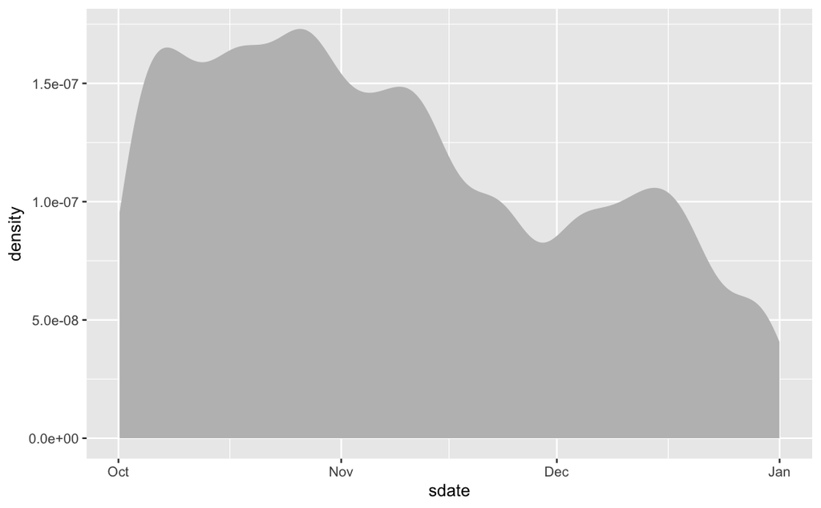

```r
Trips %>%
  ggplot(aes(x = sdate)) +
  geom_density(fill = "gray", color = NA)
```

# A.1 How Long?

```r
# select the variables of use for the activity & create a duration variable
Trips <-
  Trips %>%
  mutate(durMin = as.numeric(edate - sdate)/60)  # trip duration in minutes

# inspect data table; discern units of "durMinutes"
head(Trips)
```

| duration | sdate | sstation | edate | estation | bikeno | client | durMin |
| --- | --- | --- | --- | --- | --- | --- | --- |
| 0h 5m 32s | 2014-10-15 08:58:00 | Braddock Rd Metro | 2014-10-15 09:04:00 | Commerce St & Fayette St | W21555 | Casual | 6 |
| 0h 10m 18s | 2014-12-18 09:17:00 | 10th & Florida Ave NW | 2014-12-18 09:27:00 | 21st St & Pennsylvania Ave NW | W20694 | Registered | 10 |
| 0h 5m 11s | 2014-10-14 18:58:00 | Eastern Market Metro / Pennsylvania Ave & 7th St SE | 2014-10-14 19:03:00 | Potomac & Pennsylvania Ave SE | W00035 | Registered | 5 |
| 0h 15m 2s | 2014-10-24 18:09:00 | New Jersey Ave & R St NW | 2014-10-24 18:24:00 | Columbia Rd & Belmont St NW | W01288 | Registered | 15 |
| 0h 2m 51s | 2014-10-04 20:17:00 | 12th & Irving St NE | 2014-10-04 20:20:00 | 10th & Monroe St NE | W01296 | Registered | 3 |
| 0h 6m 59s | 2014-11-08 15:33:00 | 15th & F St NE | 2014-11-08 15:40:00 | 6th & H St NE | W01251 | Registered | 7 |

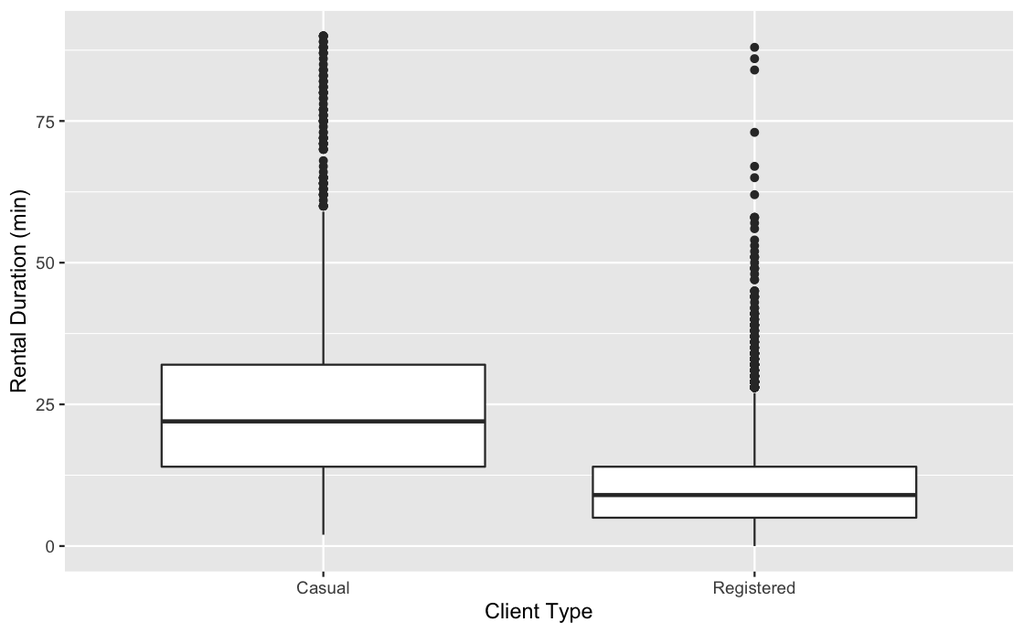

```r
# boxplot
Trips %>%
  ggplot(aes(x = client, y = durMin)) +
  geom_boxplot() +
  ylim(0, 90) +           # restrict plot to 90 minutes or less
  ylab("Rental Duration (min)") +
  xlab("Client Type")
```

# A.2 When are bikes used?

Explore bike use for the following:

- day of the year (1 to 365)
- day of the week (Sunday to Saturday)
- hour of the day (0 to 24)
- minute in the hour (0 to 60)

We first need to create these variables in the `Trips` data table using a `mutate()` statement.

```r
Trips <-
  Trips %>%
  mutate(dayOfYear = lubridate::yday(sdate),
         dayOfWeek = lubridate::wday(sdate),
         dayOfWeekLabel = lubridate::wday(sdate, label = TRUE),
         hourOfDay = lubridate::hour(sdate),
         minuteOfHour = lubridate::minute(sdate))

# head(Trips)     # Inspect data table (commented out for now)
```

##### Day of the year (1 to 365)

The data suggest that usage declines toward the end of the year. (Note: the data set is said to include “rental history over the last quarter of 2014” so there is no information in this data set for January through September)

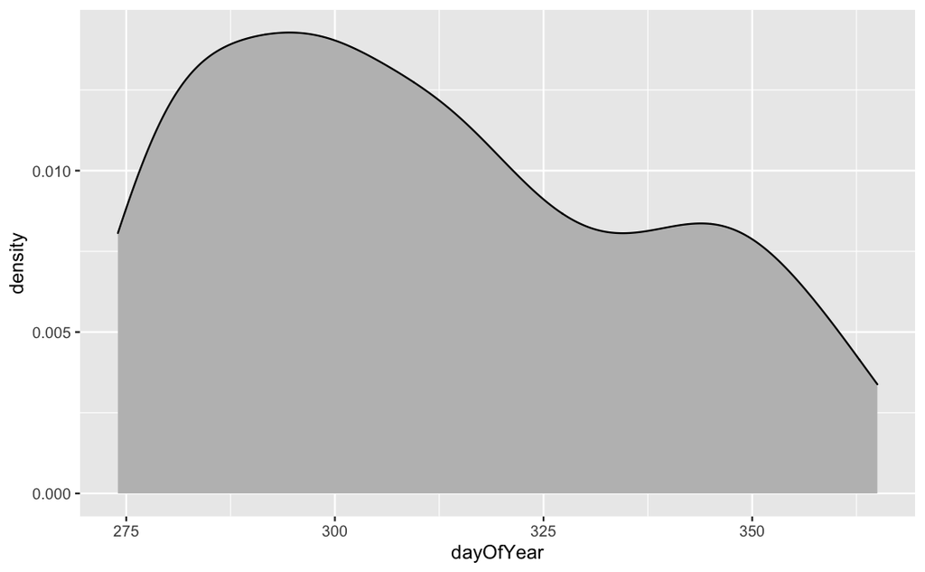

```r
Trips %>%
  ggplot(aes(x = dayOfYear)) +
  geom_density(fill = "gray", adjust = 2)
```

##### Day of the week (Sunday to Saturday)

We see usage is quite consistent across the weekdays, and then a bit reduced on weekends.

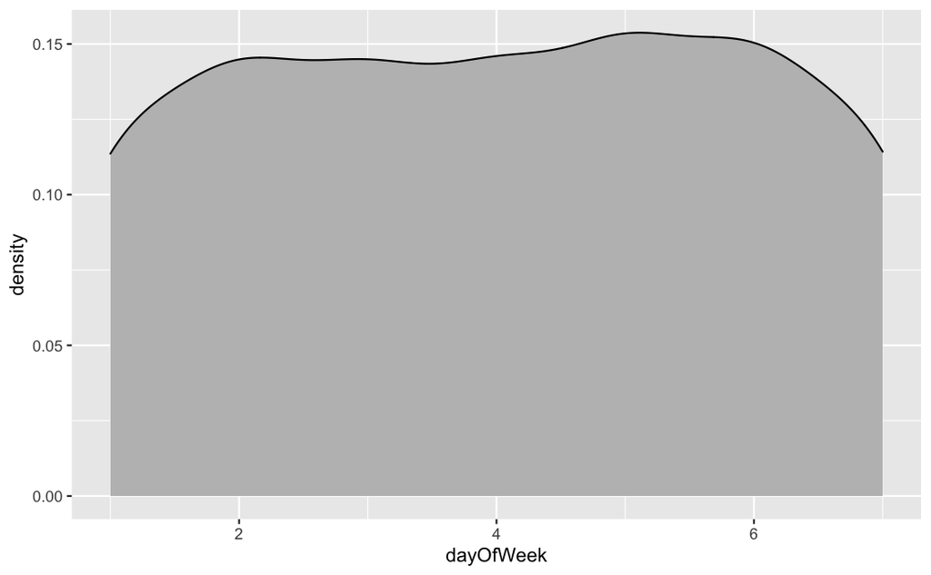

```r
Trips %>%
  ggplot(aes(x = dayOfWeek)) +
  geom_density(fill = "gray", adjust = 2)
```

Density isn’t wrong, but it’s a little goofy here. Actually, it’s pretty easy to turn the day of week from numeric to the names as we know them with `dayOfWeekLabel = lubridate::wday(sdate, label = TRUE)` so let’s do that and make it a bar chart to see how that looks.

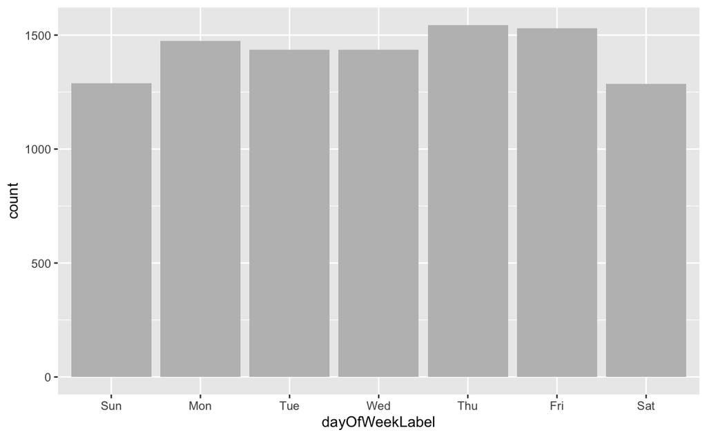

```r
Trips %>%
  ggplot(aes(x = dayOfWeekLabel)) +
  geom_bar(fill = "gray")
```

##### Hour of the day (0 to 24)

Few bicycles are checked out before 5am, and then we see usage spike near 8am and 5pm in concert with rush hour commuting.

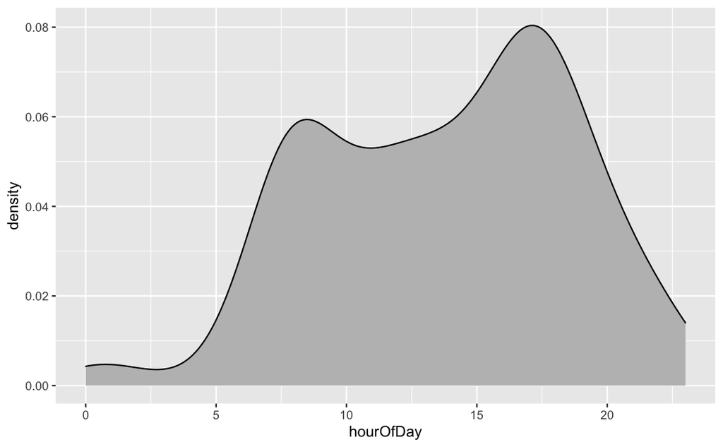

```r
Trips %>%
  ggplot(aes(x = hourOfDay)) +
  geom_density(fill = "gray", adjust = 2)
```

##### Minute in the hour (0 to 60)

Usage appears to drop near the top of the hour.

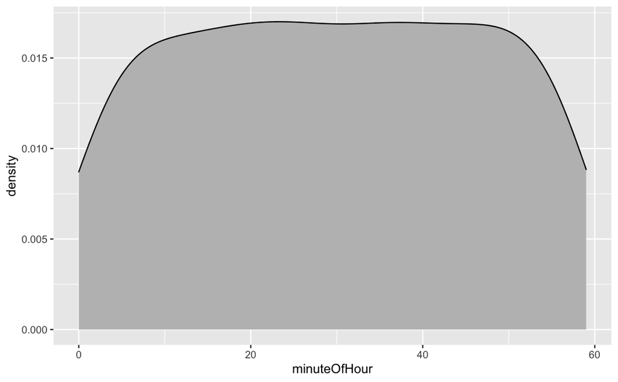

```r
Trips %>%
  ggplot(aes(x = minuteOfHour)) +
  geom_density(fill = "gray", adjust = 2)
```

##### Group the bike rentals by hour, weekday, & client type

We can see that the rush hour spikes (8am & 5pm) are much more pronounced among registered users on weekdays.

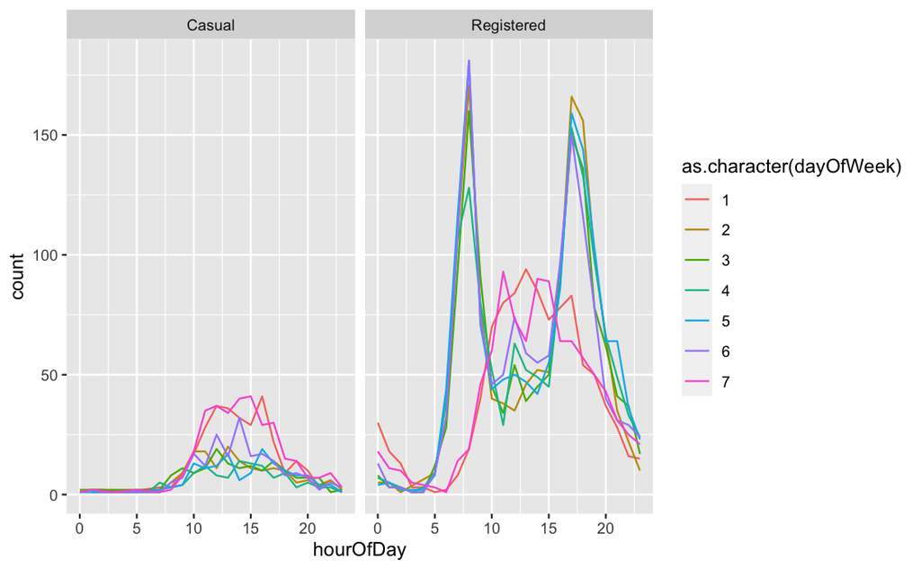

```r
Trips %>%
  group_by(client, dayOfWeek, hourOfDay) %>%
  summarise(count = n()) %>%
  ggplot(aes(x = hourOfDay, y = count)) +
  geom_line(aes(group = dayOfWeek, color = as.character(dayOfWeek))) +
  facet_wrap( ~ client)
```

##### Construct a similar plot using density rather than frequency

The density appears to present the information in a more “relative” than “absolute” way. The density could be misinterpreted to suggest that bicycle usage among casual users is higher than registered users.

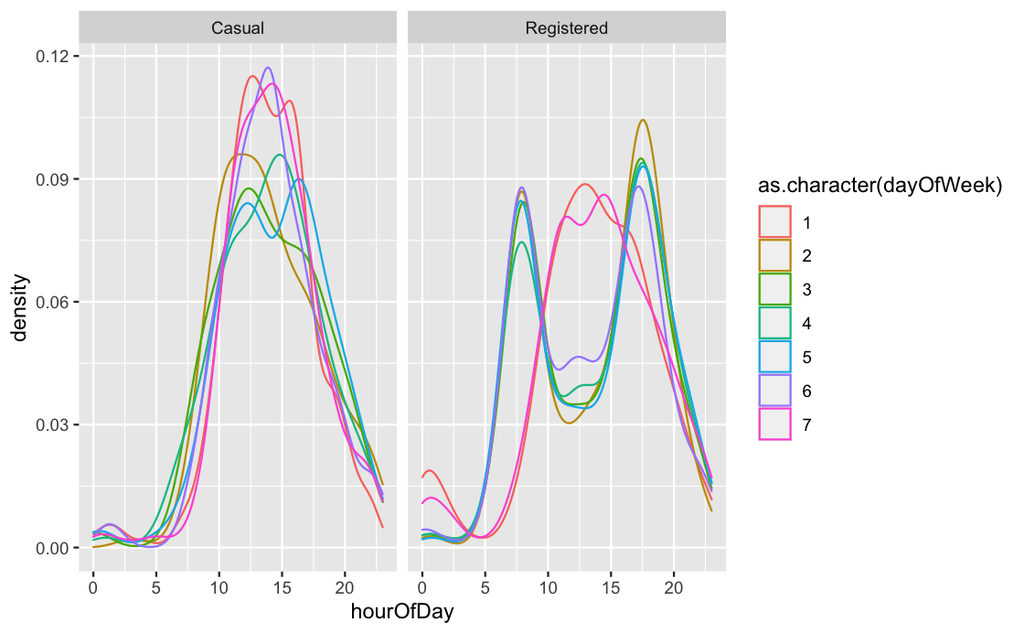

```r
Trips %>%
  ggplot(aes(x = hourOfDay)) +
  geom_density(aes(group = dayOfWeek, color = as.character(dayOfWeek))) +
  facet_wrap( ~ client)
```

# A.3 How Far?

We want to calculate the distance between stations using the `haversine()` function.

```r
source("https://mdbeckman.github.io/dcSupplement/R/haversine.R")
```

We want to create a table where a case is a *pair* of stations. We first need to create tables that represent the starting station and another table that represents the ending station in each pair. Since we ultimately want to join this information with the `Trips` data, we use the variable names `sstation` and `estation` since those represent the starting and ending stations we will want to match from that data table.

```r
# inspect the Stations data
head(Stations)
```

| name | lat | long | nbBikes | nbEmptyDocks |
| --- | --- | --- | --- | --- |
| 20th & Bell St | 38.85610 | -77.05120 | 7 | 4 |
| 18th & Eads St. | 38.85725 | -77.05332 | 8 | 3 |
| 20th & Crystal Dr | 38.85640 | -77.04920 | 8 | 7 |
| 15th & Crystal Dr | 38.86017 | -77.04959 | 9 | 2 |
| Aurora Hills Community Ctr/18th & Hayes St | 38.85787 | -77.05949 | 7 | 4 |
| Pentagon City Metro / 12th & S Hayes St | 38.86230 | -77.05994 | 7 | 12 |

```r
# create a working copy of the data & rename to identify starting Station
Simple <-
  Stations %>%
  rename(sstation = name)

# create another copy and rename variables for use as the ending station
Simple2 <-
  Simple %>%
  rename(estation = sstation, lat2 = lat, long2 = long)

# inspect Simple & Simple2
head(Simple)
```

| sstation | lat | long | nbBikes | nbEmptyDocks |
| --- | --- | --- | --- | --- |
| 20th & Bell St | 38.85610 | -77.05120 | 7 | 4 |
| 18th & Eads St. | 38.85725 | -77.05332 | 8 | 3 |
| 20th & Crystal Dr | 38.85640 | -77.04920 | 8 | 7 |
| 15th & Crystal Dr | 38.86017 | -77.04959 | 9 | 2 |
| Aurora Hills Community Ctr/18th & Hayes St | 38.85787 | -77.05949 | 7 | 4 |
| Pentagon City Metro / 12th & S Hayes St | 38.86230 | -77.05994 | 7 | 12 |

```r
head(Simple2)
```

| estation | lat2 | long2 | nbBikes | nbEmptyDocks |
| --- | --- | --- | --- | --- |
| 20th & Bell St | 38.85610 | -77.05120 | 7 | 4 |
| 18th & Eads St. | 38.85725 | -77.05332 | 8 | 3 |
| 20th & Crystal Dr | 38.85640 | -77.04920 | 8 | 7 |
| 15th & Crystal Dr | 38.86017 | -77.04959 | 9 | 2 |
| Aurora Hills Community Ctr/18th & Hayes St | 38.85787 | -77.05949 | 7 | 4 |
| Pentagon City Metro / 12th & S Hayes St | 38.86230 | -77.05994 | 7 | 12 |

In order to create pairs matching every single beginning station to every single ending station, we need a type of join called a Cartesian product of our startStation & endStation data tables. The book explains that Cartesian products can be dangerous if the tables are too large, so you need to think before you do a join like this. With 347 cases in each data table, the Cartesian product results in $347 * 347 = 120409$ cases. This is certainly a manageable size, so we’ll proceed.

```r
# join the starting and ending data tables together
StationPairs <-
  merge(Simple, Simple2, by = NULL)

# inspect station pairs data table
head(StationPairs)
```

|  | sstation | lat | long | nbBikes.x | nbEmptyDocks.x | estation | lat2 | long2 | nbBikes.y | nbEmptyDocks.y |
| --- | --- | --- | --- | --- | --- | --- | --- | --- | --- | --- |
| 1 | 20th & Bell St | 38.85610 | -77.05120 | 7 | 4 | 20th & Bell St | 38.8561 | -77.0512 | 7 | 4 |
| 2 | 18th & Eads St. | 38.85725 | -77.05332 | 8 | 3 | 20th & Bell St | 38.8561 | -77.0512 | 7 | 4 |
| 3 | 20th & Crystal Dr | 38.85640 | -77.04920 | 8 | 7 | 20th & Bell St | 38.8561 | -77.0512 | 7 | 4 |
| 4 | 15th & Crystal Dr | 38.86017 | -77.04959 | 9 | 2 | 20th & Bell St | 38.8561 | -77.0512 | 7 | 4 |
| 5 | Aurora Hills Community Ctr/18th & Hayes St | 38.85787 | -77.05949 | 7 | 4 | 20th & Bell St | 38.8561 | -77.0512 | 7 | 4 |
| 6 | Pentagon City Metro / 12th & S Hayes St | 38.86230 | -77.05994 | 7 | 12 | 20th & Bell St | 38.8561 | -77.0512 | 7 | 4 |

```r
# compute distances with haversine()
PairDistances <-
  StationPairs %>%
  transmute(sstation, estation, distance = haversine(lat, long, lat2, long2)) %>%
  select(sstation, estation, distance)

# inspect PairDistances
head(PairDistances)
```

|  | sstation | estation | distance |
| --- | --- | --- | --- |
| 1 | 20th & Bell St | 20th & Bell St | 0.0000000 |
| 2 | 18th & Eads St. | 20th & Bell St | 0.2237177 |
| 3 | 20th & Crystal Dr | 20th & Bell St | 0.1763635 |
| 4 | 15th & Crystal Dr | 20th & Bell St | 0.4734716 |
| 5 | Aurora Hills Community Ctr/18th & Hayes St | 20th & Bell St | 0.7441989 |
| 6 | Pentagon City Metro / 12th & S Hayes St | 20th & Bell St | 1.0236764 |

```r
NA
```

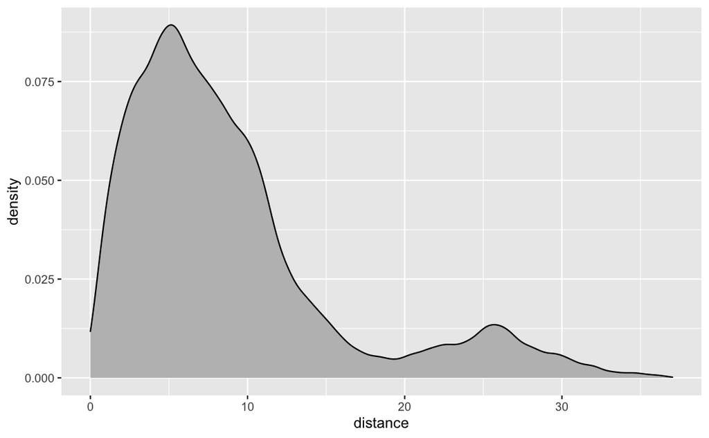

```r
PairDistances %>%
  ggplot(aes(x = distance)) +
  geom_density(fill = "gray")
```

The book says that “one end of Washington DC to the other is about 14.1 miles” so we need to investigate a bit further since our density plot of station distances doesn’t seem to reflect that. We see below that the furthest stations are about 37.03506 (units) apart. We might first suspect (correctly) that the “units” produced by the `haversine()` function are kilometers and not miles. Still, 14.1 miles is less than 23 km, but our largest possible distance pair is 37.03506 km (23 miles) from “Needwood Rd & Eagles Head Ct” to “Prince St & Union St”. A quick investigation using [Google Maps](https://goo.gl/maps/c2gecqmEeaP2) reveals a walking distance of about 25 miles between those locations. Walking distance can come close to the true distance “as the crow flies” but a few minor detours would be required in order to walk on paved paths, cross the Potomac River, etc. It looks like the distances have been calculated correctly, but the “hint” in the text book was perhaps misleading since “one end to the other” isn’t necessarily the diameter between the most extreme points (i.e. corner to corner).

```r
PairDistances %>%
  arrange(desc(distance)) %>%
  head()
```

|  | sstation | estation | distance |
| --- | --- | --- | --- |
| 1 | Needwood Rd & Eagles Head Ct | Prince St & Union St | 37.03506 |
| 2 | Prince St & Union St | Needwood Rd & Eagles Head Ct | 37.03506 |
| 3 | Shady Grove Metro West | Prince St & Union St | 36.84887 |
| 4 | Prince St & Union St | Shady Grove Metro West | 36.84887 |
| 5 | Needwood Rd & Eagles Head Ct | Market Square / King St & Royal St | 36.79420 |
| 6 | Market Square / King St & Royal St | Needwood Rd & Eagles Head Ct | 36.79420 |

Next, we want to join the `PairDistances` table with `Trips` to calculate the start-to-end distance of each trip.

```r
RideDistances <-
  Trips %>%
  inner_join(PairDistances, by = c("sstation", "estation"))
```

The distances of the actual rides tend to be only a few kilometers or less. Most rides are between stations that are fewer than about 5 kilometers apart. Of course, the ride itself may be longer, but the stations aren’t very far apart in absolute distance. Most of the station pairs are farther apart than 5 km, but people don’t tend to use the bicycle share program to travel that far since other transportation would probably be much more efficient (and possibly safer?) as travel distance increases.

Note: for the purpose of the assignment, it’s fine to just show the plot of ride distances without adding the layer to show distance between pairs of stations on the same plot.

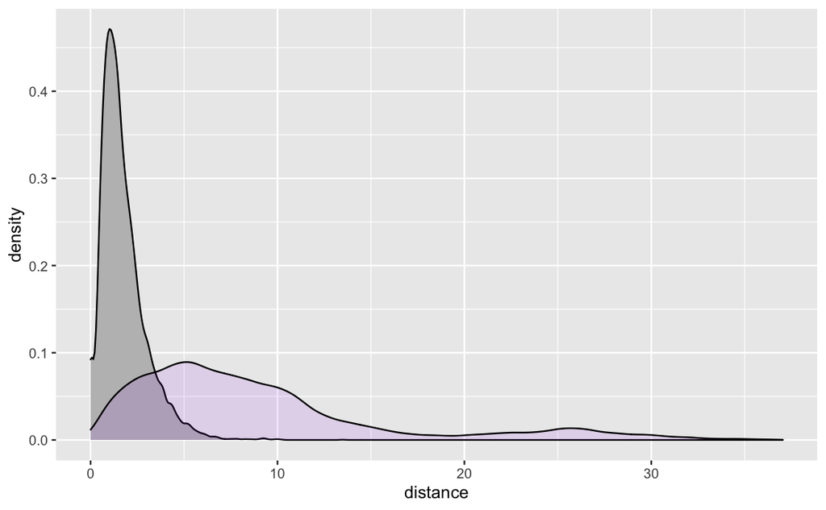

```r
RideDistances %>%
  ggplot(aes(x = distance)) +
  geom_density(fill = "gray") +
  geom_density(data = PairDistances, aes(x = distance), fill = "purple", alpha = 0.1)
```

# A.4 Mapping the Stations

```r
stationMap <-
  leaflet(Stations) %>%
  addTiles() %>%
  addCircleMarkers(radius = 2, color = "red") %>%
  setView(-77.04, 38.9, zoom = 12)
```

```
Assuming "long" and "lat" are longitude and latitude, respectively
```

```r
stationMap
```

[interactive chart not shown]

# A.5 Long-distance stations (Extra Credit)

```r
StationPairMap <-
  RideDistances %>%
  rename(name = sstation) %>% # rename to facilitate join operation
  left_join(Stations) %>%     # adds lat & long
  transmute(name, lat, long, distProxy = distance * 1000/3) %>%
  group_by(name, lat, long) %>%
  summarise(medDist = median(distProxy))
head(StationPairMap)
```

| name | lat | long | medDist |
| --- | --- | --- | --- |
| 10th & E St NW | 38.89591 | -77.02606 | 379.7529 |
| 10th & Florida Ave NW | 38.92039 | -77.02567 | 434.7858 |
| 10th & Monroe St NE | 38.93251 | -76.99289 | 977.4372 |
| 10th & U St NW | 38.91720 | -77.02590 | 460.0599 |
| 10th St & Constitution Ave NW | 38.89303 | -77.02601 | 493.1474 |
| 11th & F St NW | 38.89786 | -77.02697 | 634.8880 |

```r
distanceMap <-
  leaflet(StationPairMap) %>%
  addTiles() %>%
  addCircleMarkers(radius = 2, color = "red") %>%
  addCircles(radius = ~ medDist, color = "blue", opacity = 0.0001) %>%
  setView(-77.04, 38.9, zoom = 12)
```

```
Assuming "long" and "lat" are longitude and latitude, respectively
Assuming "long" and "lat" are longitude and latitude, respectively
```

```r
distanceMap
```

[interactive chart not shown]

```r
NA
```

Based on the map, the median distance traveled from each station appears to be negatively correlated with station density. In other words, when there are many stations in close proximity the median ride distance tends to be shorter by comparison to areas of the city where the ride stations are more sparse.

With a small modification (i.e. `addCircleMarkers(radius = 2, color = "red", opacity = ~ freqUsage)`), we can darken the location marker of each bicycle share station to reflect the frequency of it’s use. With this information included, the plot below shows that near the city center rides tend to be shorter distances and the stations are utilized much more frequently. By contrast, near the fringes of the city rides tend to be longer distances and the stations are utilized less frequently.

```r
StationPairMap <-
  RideDistances %>%
  rename(name = sstation) %>% # rename to facilitate join operation
  left_join(Stations) %>%     # adds lat & long
  transmute(name, lat, long, distProxy = distance * 1000/3) %>%
  group_by(name, lat, long) %>%
  summarise(medDist = median(distProxy), freqUsage = 0.0002 * n())
freqMap <-
  leaflet(StationPairMap) %>%
  addTiles() %>%
  addCircleMarkers(radius = 2, color = "red", opacity = ~ freqUsage) %>%
  addCircles(radius = ~ medDist, color = "blue", opacity = 0.0001) %>%
  setView(-77.04, 38.9, zoom = 12)
```

```
Assuming "long" and "lat" are longitude and latitude, respectively
Assuming "long" and "lat" are longitude and latitude, respectively
```

```r
freqMap
```

[interactive chart not shown]

```r
NA
```